# Instalación & Actualización

Mayo, 2015

## Descargando R

La descarga del programa R se describe en los siguientes pasos:

- Accedemos a la página web del R Project a través de un navegador tecleando la dirección: http://www.r-project.org.

[figure not shown]

- Ingresamos a la CRAN para elegir un repositorio cercano a nuestra localidad. En nuestro caso seleccionamos el repositorio de la Escuela Politécnica de Litoral.

## Descargando R

- Nos dirigimos a la parte superior de la página, y nos ubicamos en *Download and install R* seguido elegimos el sistema operativo. Para nuestro caso hacemos click en *Windows*.

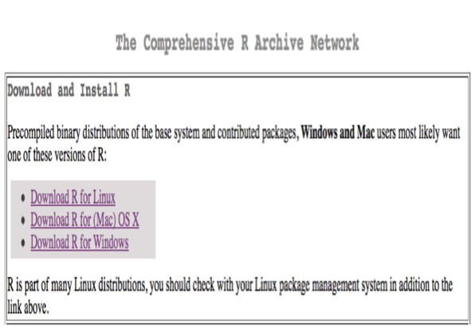

- Elegimos entre los 3 subdirectorios: *base*, *contrib* y *RTools*. Damos click sobre *base*.

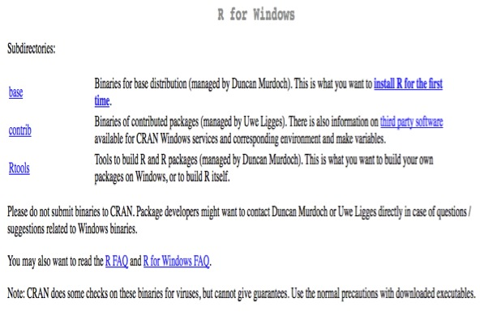

## Descargando R

- Finalmente, en la pantalla damos click sobre *Download R X.Y.Z for Windows*, con lo cual descargamos la versión de R más reciente.

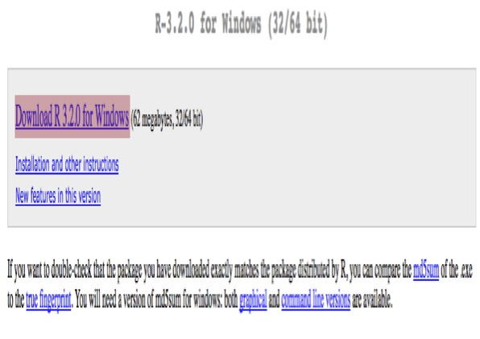

En la actualidad, el software R puede ser instalado incluso sobre la plataforma Android https://play.google.com/store/apps/details?id=com.appsopensource.R&hl=es_419, esto permite que muchos usuarios puedan tener acceso al programa en todo momento con tan sólo contar con un smartphone operativo.

## Instalando R

Una vez obtenido el programa ejecutable procedemos a dar doble click.

- Seleccionamos el idioma para la instalación

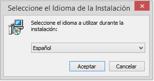

[figure not shown]

[figure not shown]

[figure not shown]

- Aceptamos todo por default

[figure not shown]

[figure not shown]

[figure not shown]

[figure not shown]

## Instalando R

- Para el acceso a la CRAN desde redes con seguridad colocamos en: **Internet 2**.

[figure not shown]

[figure not shown]

[figure not shown]

- Finalmente, esperamos que se instale el programa.

[figure not shown]

## Repositorios

Las capacidades de R pueden ser ampliadas fácilmente mediante la incorporación de paquetes que se encuentran disponibles en varios repositorios, tales como:

- CRAN
- BioConductor
- Github
- Omegahat
- MRAN
- RForge

#### METÁFORA:

Imaginemos que tener instalado el programa en el computador es como haber adquirido un auto nuevo el cual cumple con ciertas funciones principales y no trae contratiempos, una vez que lo empezamos a rodar nos vamos dando cuenta de la necesidad de mejorar el rendimiento de ciertos mecanismos ya existentes del auto debido que lo vamos exponiendo a diferentes ambientes y condiciones. Lo anterior pasa exactamente con R, cuando descargamos e instalamos el sotfware contamos con ciertas características y paquetes básicos pero existen miles de paquetes adicionales que pueden ser agregados para lograr mejorar su funcionalidad y a la vez realizar cosas estupendas.

## Paquetes estándar

```r
search()
```

```
##  [1] ".GlobalEnv"        "package:knitr"     "package:stats"
##  [4] "package:graphics"  "package:grDevices" "package:utils"
##  [7] "package:datasets"  "package:methods"   "Autoloads"
## [10] "package:base"
```

Las librerías mantienen un orden dentro de R para la búsqueda de funciones.

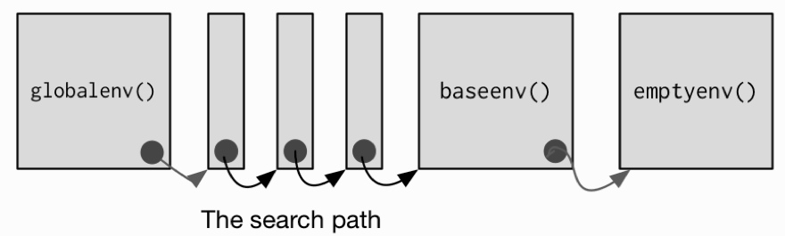

## Instalación de paquetes

### Repositorio CRAN

La instalación de paquetes en R desde el repositorio CRAN es sencillo, una vez conocido el nombre del paquete a instalarse basta con introducir el siguiente comando en la consola:

```r
install.packages("nombre_paquete")
```

Ciertos paquetes de R requieren la instalación de otros paquetes adicionales debido que entre estos comparten algunas funciones () para evitar tener inconvenientes con la instalación de un paquete se aconseja adicionar el parametro siguiente:

```r
install.packages("nombre_paquete", dependencies=TRUE)
```

En el caso que se desee instalar un lista de \(n\) paquetes planteamos la siguiente solución:

```r
paquetes <- c("pckg_1","pckg_2", ... , "pckg_n")
lapply(seq_along(paquetes), function(i){
      install.packages(paquetes[[i]], dependencies=TRUE)
      })
```

## Instalación de paquetes

### Repositorios externos

Habiamos comentado sobre la existencia de varios repositorios adicionales al CRAN de entre los cuales destacan R-Forge, BioConductor y Omegahat, dentro de estos repositorios se pueden encontrar paquetes que no se encuentran en el CRAN, o bien, versiones más actualizadas de los mismos.

Para instalar los paquetes desde los repositorios externos antes mencionados basta la siguiente sentencia:

```r
install.packages("pckgname", repos="http://r-forge.r-project.org")
install.packages("pckgname", repos="http://www.omegahat.org/R")
install.packages("pckgname", repos="http://www.bioconductor.org/
                                    packages/2.10/bioc")
```

Algunos de los paquetes se encuentran en formato binario, para su instalación basta adicionar el parámetro *type="source"*.

```r
install.packages("pckgname", repos="http://r-forge.r-project.org", type="source")
```

## Instalación de paquetes

### Repositorios Github

En la actualidad gran cantidad de usuarios R han alojado sus proyectos en el sistema de control de versiones GitHub, Inc. por lo cual se hace necesario contar con una solución al momento de instalar algún paquete alojado en dicho sistema.

```r
install.packages('devtools', dependencies=TRUE)
devtools::install_github("rstudio/rmarkdown")
```

Iniciamos instalando el paquete *devtools* el cual nos provee la función *install-github*, esta última es la encargada de acceder al sistema Github e instalar el paquete deseado, para esta ocasión hemos seleccionado el paquete *rmarkdown* alojado en el repositorio del proyecto *rstudio*.

[figure not shown]

## Cargando paquetes

Una vez instalado un paquete el paso siguiente consiste en cargar las funciones y datos del mismo dentro del área de trabajo, para esto tenemos dos comandos útiles: **library( )** y **require( )**, sin embargo lo más recomendable es utilizar el primero de ellos como se detalla a continuación:

```r
library('translate2R')
```

```
## Error in library("translate2R"): there is no package called 'translate2R'
```

```r
require('translate2R')
```

Una solución para usar **require( )** consiste en añadir el parámetro **quietly = TRUE**.

## Paquetes instalados

Para visualizar el listado completo de los paquetes instalados podemos recurrir al comando **library( )**. Además, si deseamos conocer el lugar en el cual se instalan los paquetes podemos hacer lo siguiente:

```r
.libPaths()
```

```
## [1] "/Library/Frameworks/R.framework/Versions/3.1/Resources/library"
```

Conocer la totalidad de paquetes que se encuentran albergados en la CRAN, y a su vez verificar cuales de ellos se encuentran válidos y disponibles para su uso es posible mediante los siguientes comandos:

```r
installed.packages()
available.packages()
```

## Información paquetes

En el caso que se requiera información acerca de un paquete previamente instalado podemos recurrir a:

```r
library(help='pckgname')
```

También podemos enlistar todas las funciones que han sido implementadas dentro de un paquete como muestra el siguiente ejemplo:

```r
library(foreign)
ls('package:foreign')
```

Si deseamos conocer los parámetros de cada una de las funciones implementadas dentro de un paquete podemos recurrir a lo siguiente:

```r
lsf.str('package:foreign')
```

Cuando un paquete es empleado dentro de una investigación surge la necesidad de citar a los autores del paquete, lo anterior lo solventamos mediante el comando **citation**.

```r
citation("foreign")
```

## Actualización paquetes

Para enlistar los paquetes que necesitan ser versionados o actualizamos, usamos el comando:

```r
update.packages()
```

Por otro lado, para enlistar los paquetes que no poseen versionamientos tenemos:

```r
old.packages()
```

Los autores de los paquetes pueden ser enlistamos mediante:

```r
lapply(dir(R.home("library")), packageDescription)
```

## Actualización de R

Mantener actualizado R y sus paquetes es relativamente fácil a través del tecleo de los siguientes comandos:

```r
install.packages('installr', dependencies = TRUE)
library('installr')
updateR()
```

El paquete **installr** posee funciones interesantes para actualizar e instalar: R, RStudio, Git, etc.

```r
library('installr')
ls("package:installr")
```

## Eliminación

Para ocasiones en las cuales se desee eliminar un paquete previamente instalado en R tenemos dos alternativas: la primera consiste básicamente en eliminar la carpeta que contiene dicho paquete del repositorio del computador mientras que la segunda alternativa consiste en emplear el siguiente comando:

```r
remove.packages("nombre_paquete", "directorio")
```

donde:

- **nombre-paquete:** Nombre o vector de nombres de los paquetes ha ser eliminados.
- **directorio:** Es un vector de caracteres que proporcionan la dirección del directorio del cual se eliminará el paquete. Si se omite dicho parámetro se asume por default la dirección obtenida por **.libPaths()**.

## Obteniendo ayuda

Existen algunas funciones en R que nos facilitan la vida al momento de indagar sobre la funcionalidad de ciertos comandos:

Por ejemplo, si nos encontramos interesados en obtener información acerca de la función **seq** podemos escribir en la consola lo siguiente:

```r
help(seq)
```

Una forma alternativa es

```r
?seq
```

Adicionalmente, si nos encontramos interesados en buscar información relacionada a un término en específico:

```r
help.search("termino_especifico")
```

En el caso de requerir un manual de ayuda completo en formato HMTL, tecleamos en la consola lo siguiente:

```r
help.start()
```

## Obteniendo ayuda

Por último, existen circunstancias en las cuales se hace indispensable conocer todas las funciones relacionadas a un nombre en específico.

Primero mostramos un ejemplo en el cual se obtienen todas las funciones relacionadas con el término **mean**.

```r
apropos("mean")
```

```
##  [1] ".colMeans"     ".rowMeans"     "colMeans"      "kmeans"
##  [5] "mean"          "mean.Date"     "mean.POSIXct"  "mean.POSIXlt"
##  [9] "mean.default"  "mean.difftime" "rowMeans"      "weighted.mean"
```

Ahora enlistamos las funciones que tiene un número entre el 4 y 8.

```r
apropos("[4-8]")
```

```
##  [1] ".TAOCP1997init" ".__C__S4"       "Harman74.cor"   "asS4"
##  [5] "enc2utf8"       "fixPre1.8"      "intToUtf8"      "isS4"
##  [9] "seemsS4Object"  "state.x77"      "utf8ToInt"
```

## Obteniendo ayuda

```r
apropos("w$")
```

```
##  [1] ".__C__raw"         "NROW"              "View"
##  [4] "all.equal.raw"     "ar.yw"             "as.data.frame.raw"
##  [7] "as.raw"            "charToRaw"         "dev.new"
## [10] "file.show"         "grepRaw"           "is.raw"
## [13] "layout.show"       "n2mfrow"           "new"
## [16] "nrow"              "pat_brew"          "pat_rnw"
## [19] "plot.new"          "plot.window"       "rainbow"
## [22] "raw"               "row"               "show"
## [25] "tryNew"            "url.show"          "window"
```

## Git & Github

- Configuración e instalación de Git.

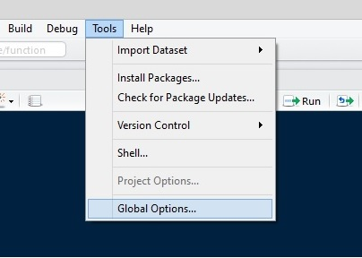

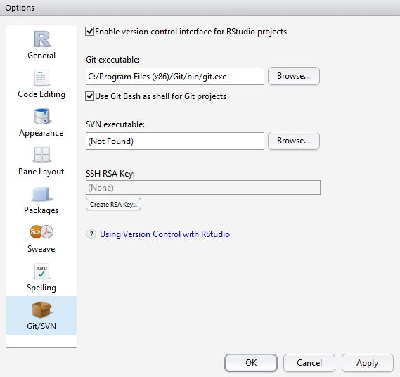

- Enlazamos Git con Github.

[figure not shown]

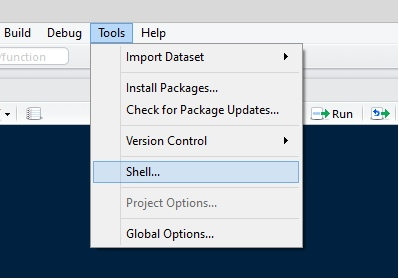

## Revolution Analytics

- Fundada en el año 2007 con la finalidad de dar soporte comercial al software **Revolution R**.
- Provee componentes tales como: ParallelR, RevoScaleR, RevoDeployR, etc.

[figure not shown]

- Modificaron el código fuente de R, lo cual ha permitido que R sea multicore, es decir, a través de estas modificaciones se logra aprovechar al máximo la funcionalidad de todos los núcleos de los procesadores del computador.
- Puede ser obtenido a través de la página web http://www.revolutionanalytics.com como **Revolution R Open** de forma gratuita, sin embargo en el caso de requerir soporte se puede adquirir la versión pagada **Revolution R Enterprise**.

## Preguntas

[figure not shown]